# SATICA — BOLETÍN DE ALERTAS TEMPRANAS N° 7

## 1. Resumen Ejecutivo de Riesgo

Este resumen presenta el estado actual de las haciendas integradas en el sistema, clasificadas de acuerdo con su evolución estadística en el ciclo calculado. Esta visión permite estratificar el esfuerzo operativo de la corporación desde la respuesta inmediata hasta el seguimiento preventivo.

A continuación se detalla la semaforización oficial del riesgo territorial:

- **CRÍTICO (🔴 Rojo):** Alta probabilidad de ocurrencia inmediata (-1 a +1 mes).
- **ALTO (🟠 Naranja):** Evento inminente/se encuentra rezagado (1 a 2 meses de diferencia).
- **OBSERVACIÓN (🟡 Amarillo):** Alerta Temprana o Seguimiento (2 a 3 meses de diferencia).
- **BAJO (🟢 Verde):** Predio se encuentra sin riesgo estadístico (> -3 meses).
- **MITIGADO (🔘 Gris):** Ciclo Roto. Riesgo desaparece (> +3 meses).

**Balance de Control Territorial:** El sistema SATICA detecta actualmente **369** haciendas en niveles de riesgo CRÍTICO y ALTO. De estas, la corporación ya ha desplegado control y auditoría en **0** predios, dejando **369** haciendas pendientes de intervención prioritaria.

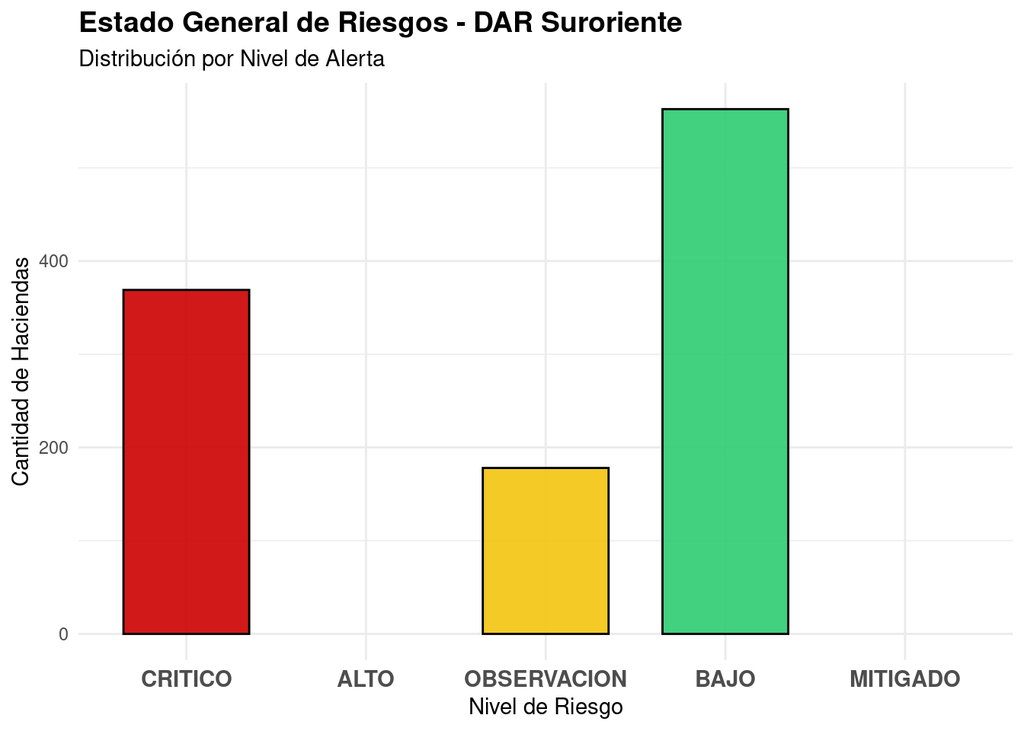

| Nivel de Riesgo | N° de Haciendas |
| --- | --- |
| CRITICO | 369 |
| OBSERVACION | 178 |
| BAJO | 563 |

## 2. Cronograma de Alertas Inminentes (Ventana ±15 Días)

Este listado es un cronograma estricto que identifica **únicamente** los predios que se encuentran en la ventana máxima de vulnerabilidad (a 15 días o menos de cumplir su ciclo estimado, o con un rezago máximo de 15 días).

### ✅ No se registran alertas inminentes en la ventana operativa (±15 días) para este ciclo.

## 3. Focalización Operativa (Top 10 por Municipio)

A continuación, se presentan las haciendas priorizadas por municipio de la DAR Suroriente. Este listado muestra únicamente las 10 haciendas con mayor recurrencia histórica por zona. Conocer la fecha de su último evento permite cruzar patrones de ocurrencia y realizar un seguimiento preventivo más eficiente.

### Municipio: CANDELARIA

| Hacienda | Corregimiento | Ingenio | Riesgo | Último Evento | Historial | Gestión CVC | Coordenadas |
| --- | --- | --- | --- | --- | --- | --- | --- |
| EL COFRE_18 | LA REGINA | MAYAGÜEZ | CRITICO | 2025-09-23 | 53 | Sin Intervención | 3.3747, -76.3411 |
| MARGARITAS_0448 | SAN JOAQUIN | CENTRAL CASTILLA | OBSERVACION | 2026-04-06 | 49 | Sin Intervención | 3.3853, -76.4184 |
| EL ARENAL_48 | ARENAL | MAYAGÜEZ | OBSERVACION | 2026-04-05 | 49 | Sin Intervención | 3.3897, -76.3561 |
| POTRERO DE PA RRAGA_36 | ARENAL | MAYAGÜEZ | CRITICO | 2023-09-14 | 47 | Sin Intervención | 3.3892, -76.3497 |
| EL COFRE CASASFRANCO_010250 | CABUYAL | INCAUCA | CRITICO | 2026-01-19 | 46 | Sin Intervención | 3.3093, -76.3371 |
| LA GUACA I_000204 | ARENAL | MARIA LUISA | CRITICO | 2024-11-16 | 45 | Sin Intervención | 3.4018, -76.3569 |
| ARGENTINA DIES Y LOME_C38 | CABUYAL | LA CABAÑA | CRITICO | 2026-01-08 | 31 | Sin Intervención | 3.3105, -76.3389 |
| SAN MARCOS_444 | CABUYAL | MAYAGÜEZ | BAJO | 2026-04-24 | 31 | Sin Intervención | 3.327, -76.3592 |
| CHONDULAR_940 | EL LAURO | MANUELITA | CRITICO | 2025-08-02 | 29 | Sin Intervención | 3.4517, -76.3637 |
| SAN MIGUEL_119 | SAN JOAQUIN | MANUELITA | OBSERVACION | 2026-01-07 | 26 | Sin Intervención | 3.3921, -76.4194 |

### Municipio: EL CERRITO

| Hacienda | Corregimiento | Ingenio | Riesgo | Último Evento | Historial | Gestión CVC | Coordenadas |
| --- | --- | --- | --- | --- | --- | --- | --- |
| PORVENIR_002 | EL PLACER | MANUELITA | BAJO | 2025-09-16 | 89 | Sin Intervención | 3.6154, -76.2592 |
| BRISUELAS_302 | SANTA HELENA | MAYAGÜEZ | OBSERVACION | 2026-02-22 | 36 | Sin Intervención | 3.6288, -76.2405 |
| GENOVA_2281 | SAN ANTONIO | PICHICHI | OBSERVACION | 2025-12-11 | 21 | Sin Intervención | 3.6726, -76.3873 |
| EL ALBION_080402 | SAN ANTONIO | PROVIDENCIA | OBSERVACION | 2026-04-22 | 9 | Sin Intervención | 3.6581, -76.3117 |
| SAMARIA_080104 | EL PLACER | PROVIDENCIA | BAJO | 2024-01-30 | 6 | Sin Intervención | 3.6182, -76.2882 |
| LA HOLANDA_080355 | SAN ANTONIO | PROVIDENCIA | BAJO | 2026-04-25 | 6 | Sin Intervención | 3.6543, -76.31 |
| PROVIDENCIA_080101 | SANTA HELENA | PROVIDENCIA | CRITICO | 2020-05-08 | 2 | Sin Intervención | 3.631, -76.2739 |
| LA PAZ_080102 | SANTA HELENA | PROVIDENCIA | CRITICO | 2021-07-24 | 2 | Sin Intervención | 3.6453, -76.2849 |
| LA ESMERALDA_080113 | EL PLACER | PROVIDENCIA | OBSERVACION | 2025-02-03 | 2 | Sin Intervención | 3.6207, -76.3129 |
| PIEDECHINCHE_080121 | SANTA HELENA | PROVIDENCIA | CRITICO | 2022-04-12 | 2 | Sin Intervención | 3.6229, -76.2259 |

### Municipio: FLORIDA

| Hacienda | Corregimiento | Ingenio | Riesgo | Último Evento | Historial | Gestión CVC | Coordenadas |
| --- | --- | --- | --- | --- | --- | --- | --- |
| TIERRA GRATA_0703 | EL REMOLINO | CENTRAL CASTILLA | BAJO | 2026-04-25 | 114 | Sin Intervención | 3.3053, -76.27 |
| INGENIO_000502 | SAN ANTONIO DE LOS CABALLEROS | MARIA LUISA | CRITICO | 2026-01-27 | 92 | Sin Intervención | 3.3447, -76.2853 |
| EL RETIRO_384 | EL REMOLINO | MAYAGÜEZ | BAJO | 2026-04-24 | 92 | Sin Intervención | 3.3038, -76.2782 |
| LA ESTRELLA_0725 | SAN FRANCISCO - EL LLANITO | CENTRAL CASTILLA | CRITICO | 2025-09-23 | 84 | Sin Intervención | 3.2836, -76.2232 |
| ARAUCA_32 | TARRAGONA | MAYAGÜEZ | BAJO | 2026-04-25 | 75 | Sin Intervención | 3.2925, -76.3398 |
| SAN RAFAEL H._0687 | EL LIBANO | CENTRAL CASTILLA | OBSERVACION | 2026-03-31 | 62 | Sin Intervención | 3.3023, -76.2278 |
| LA CASILDA_274 | LA DIANA | MAYAGÜEZ | BAJO | 2026-04-26 | 55 | Sin Intervención | 3.3303, -76.2267 |
| BALSILLA_0684 | EL REMOLINO | CENTRAL CASTILLA | OBSERVACION | 2026-03-18 | 49 | Sin Intervención | 3.3158, -76.2525 |
| WATERLOO_0484 | LA DIANA | CENTRAL CASTILLA | OBSERVACION | 2026-03-04 | 48 | Sin Intervención | 3.3377, -76.241 |
| RIO FRAYLE_751 | EL REMOLINO | LA CABAÑA | OBSERVACION | 2026-04-08 | 43 | Sin Intervención | 3.3286, -76.2591 |

### Municipio: PALMIRA

| Hacienda | Corregimiento | Ingenio | Riesgo | Último Evento | Historial | Gestión CVC | Coordenadas |
| --- | --- | --- | --- | --- | --- | --- | --- |
| CASCAJAL_008 | CORONADO | MANUELITA | BAJO | 2026-04-04 | 86 | Sin Intervención | 3.565, -76.3144 |
| SAN JOSE_300 | AGUACLARA | MANUELITA | BAJO | 2026-02-05 | 77 | Sin Intervención | 3.5101, -76.2643 |
| GERTRUDIS_004 | ZAMORANO | MANUELITA | CRITICO | 2025-09-23 | 72 | Sin Intervención | 3.5913, -76.274 |
| ESPERANZA INESA_081363 | GUAYABAL | PROVIDENCIA | BAJO | 2026-04-03 | 72 | Sin Intervención | 3.5412, -76.2633 |
| CASABCA/DOLORES_074 | JUANCHITO | MANUELITA | OBSERVACION | 2026-03-17 | 67 | Sin Intervención | 3.4845, -76.4649 |
| CABAA’A_001 | TIENDA NUEVA | MANUELITA | BAJO | 2025-10-04 | 47 | Sin Intervención | 3.5674, -76.247 |
| GERMANIA_367 | BARRANCAS | MANUELITA | BAJO | 2026-04-24 | 46 | Sin Intervención | 3.5334, -76.2397 |
| SANTA ROSA_347 | TIENDA NUEVA | MANUELITA | BAJO | 2026-04-25 | 41 | Sin Intervención | 3.5852, -76.2497 |
| SAN PABLO TUMACO_011948 | GUANABANAL | INCAUCA | OBSERVACION | 2026-04-11 | 40 | Sin Intervención | 3.4901, -76.4323 |
| EL PALMAR_88 | GUANABANAL | MAYAGÜEZ | BAJO | 2026-04-25 | 36 | Sin Intervención | 3.4753, -76.4178 |

### Municipio: PRADERA

| Hacienda | Corregimiento | Ingenio | Riesgo | Último Evento | Historial | Gestión CVC | Coordenadas |
| --- | --- | --- | --- | --- | --- | --- | --- |
| SARITA_0434 | PARRAGA | CENTRAL CASTILLA | OBSERVACION | 2026-01-10 | 37 | Sin Intervención | 3.3832, -76.2264 |
| EL ARADO_460 | LA FLORESTA | MANUELITA | OBSERVACION | 2026-04-10 | 33 | Sin Intervención | 3.4122, -76.2476 |
| EL TABLON BAJO_B05 | POTRERITO | LA CABAÑA | CRITICO | 2025-09-09 | 32 | Sin Intervención | 3.4293, -76.2332 |
| MAYAPAN_0676 | LA GRANJA | CENTRAL CASTILLA | CRITICO | 2025-09-25 | 28 | Sin Intervención | 3.3899, -76.2373 |
| PORVENIR LOPEZ_0260 | BOLO - HARTONAL | CENTRAL CASTILLA | OBSERVACION | 2026-03-19 | 24 | Sin Intervención | 3.4281, -76.2522 |
| ARADO 2_0706 | LA FLORESTA | CENTRAL CASTILLA | CRITICO | 2025-07-27 | 23 | Sin Intervención | 3.4121, -76.2579 |
| LA LEONA_0201 | POTRERITO | CENTRAL CASTILLA | CRITICO | 2025-09-07 | 22 | Sin Intervención | 3.4309, -76.2412 |
| MONASTIR_0436 | LA GRANJA | CENTRAL CASTILLA | CRITICO | 2025-09-26 | 19 | Sin Intervención | 3.393, -76.2258 |
| LA FLORESTA_0761 | LA FLORESTA | CENTRAL CASTILLA | CRITICO | 2023-08-04 | 16 | Sin Intervención | 3.4173, -76.2273 |
| CONCORDIA_796 | LA FLORESTA | MANUELITA | BAJO | 2026-04-22 | 16 | Sin Intervención | 3.4003, -76.2459 |

### Municipio: SIN MUNICIPIO

| Hacienda | Corregimiento | Ingenio | Riesgo | Último Evento | Historial | Gestión CVC | Coordenadas |
| --- | --- | --- | --- | --- | --- | --- | --- |
| LA MERCED CABAL HNAS._080500 | SIN DATO | PROVIDENCIA | CRITICO | 2022-09-04 | 2 | Sin Intervención | 3.6631, -76.3197 |
| LA CLARA_0637 | SIN DATO | CENTRAL CASTILLA | CRITICO | 2019-09-08 | 1 | Sin Intervención | 3.2798, -76.258 |

## 4. Ficha Detalle Técnica (Top 10 DAR Suroriente)

Esta sección consolida las haciendas prioritarias de toda la DAR Suroriente en una sola tabla matriz. Su criterio principal es la recurrencia histórica de incendios, independientemente de su nivel de riesgo actual. Esta ficha técnica facilita la consulta rápida de coordenadas y soporta el historial de las visitas institucionales realizadas al predio.

| Municipio | Hacienda | Ingenio | Nivel | Último Evento | Histórico | Gestión CVC | Coordenadas |
| --- | --- | --- | --- | --- | --- | --- | --- |
| FLORIDA | TIERRA GRATA_0703 | CENTRAL CASTILLA | BAJO | 2026-04-25 | 114 | Sin Intervención | 3.3053, -76.27 |
| FLORIDA | INGENIO_000502 | MARIA LUISA | CRITICO | 2026-01-27 | 92 | Sin Intervención | 3.3447, -76.2853 |
| FLORIDA | EL RETIRO_384 | MAYAGÜEZ | BAJO | 2026-04-24 | 92 | Sin Intervención | 3.3038, -76.2782 |
| EL CERRITO | PORVENIR_002 | MANUELITA | BAJO | 2025-09-16 | 89 | Sin Intervención | 3.6154, -76.2592 |
| PALMIRA | CASCAJAL_008 | MANUELITA | BAJO | 2026-04-04 | 86 | Sin Intervención | 3.565, -76.3144 |
| FLORIDA | LA ESTRELLA_0725 | CENTRAL CASTILLA | CRITICO | 2025-09-23 | 84 | Sin Intervención | 3.2836, -76.2232 |
| PALMIRA | SAN JOSE_300 | MANUELITA | BAJO | 2026-02-05 | 77 | Sin Intervención | 3.5101, -76.2643 |
| FLORIDA | ARAUCA_32 | MAYAGÜEZ | BAJO | 2026-04-25 | 75 | Sin Intervención | 3.2925, -76.3398 |
| PALMIRA | GERTRUDIS_004 | MANUELITA | CRITICO | 2025-09-23 | 72 | Sin Intervención | 3.5913, -76.274 |
| PALMIRA | ESPERANZA INESA_081363 | PROVIDENCIA | BAJO | 2026-04-03 | 72 | Sin Intervención | 3.5412, -76.2633 |

**Fin del Reporte SATICA**  
*Generado automáticamente por la Dirección Ambiental Regional Suroriente.*  
Fecha de emisión: 11/06/2026 22:00